# R decision tree

Jang, Eunhee

2018년 5월 30일

### 목차

1. 의사결정 트리가 무엇인가?
2. 엔트로피와 정보 획득량
3. 의사결정 트리 실습  
   - 화장품 구매 데이터  
   - 지방간 데이터  
   - 독일 은행의 대출여부 데이터
4. 의사결정 자동화 스크립트

> 의사결정 트리를 위한 사전 수학적 지식: 확률 & log함수

### 1. 의사결정 트리가 무엇인가?

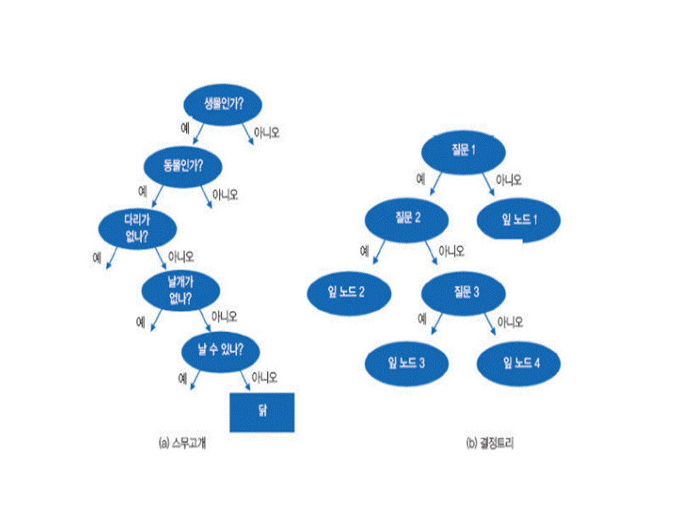

의사결정트리

> 1. 의사결정 트리란? 의사결정 rule을 계층적 나무구조로 도표화하여 분류 및 예측할 수 있는 분석방법  
>    2.장점: 결정트리를 통한 데이터 분석의 결과를 나무구조로 표현되기 때문에 분석가가 결과를 쉽게 이해하고 설명할 수 있는 장점이 있다.  
>    분류율에 대한 정확도만 따지면 신경망 또는 회귀분석등의 분류 방법들보다 낮게 평가되기도 하지만 결과를 쉽게 이해하고 설명할 수 있으며 의사결정을 하는데 직접적으로 사용할 수 있는 장점이 있다.
> 2. 종류: ID3(엔트로피), C4.5(정보획득량), C5.0(정보획득량), CART(카이제곱), CHAID(지니계수)
> 3. 고려해야할 문제
> 1. 훈련 데이터를 어떤 속성(컬럼)으로 분할해야 하는가? -> 정보획득량이 가장 높은 컬럼을 우선순위로
> 2. 트리 성장(분할과정)은 언제, 어떻게 정지해야하는가? -> 의사결정 트리를 시각화 하여 순도가 높게 분류되는지 확인하기
> 3. 과적합 문제는 어떻게 해결해야 하느나? -> 가지치기(tree pruning)를 이용해서 불필요한 질문을 제거한다.

### 2. 엔트로피와 정보 획득량

> **이때 가장 중요한 질문을 처음에 해야 빨리 정답을 맞출 수 있다.**

> 그 질문의 우선순위를 정할 때 필요한게 엔트로피(entropy)이다.  
> **엔트로피: 불확실성의 정도를 의미** (불순도)

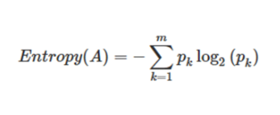

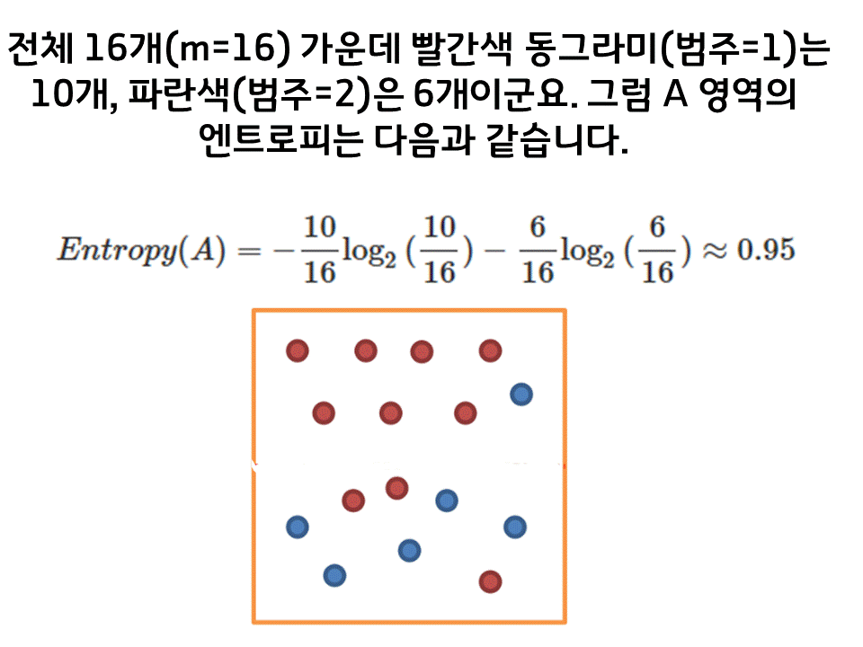

> 범주 = k, 범주의 갯수 = m

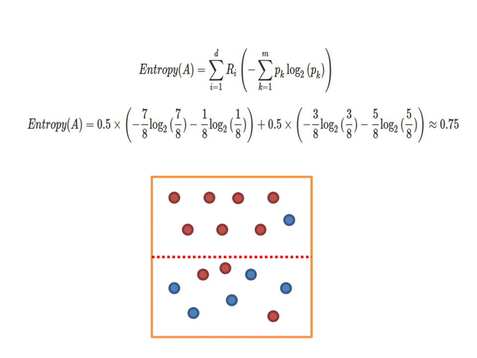

> 분할한 상태의 불순도 구하기

> 정보획득량: 분할전 엔트로피 - 분할 후 엔트로피

#### 예제:

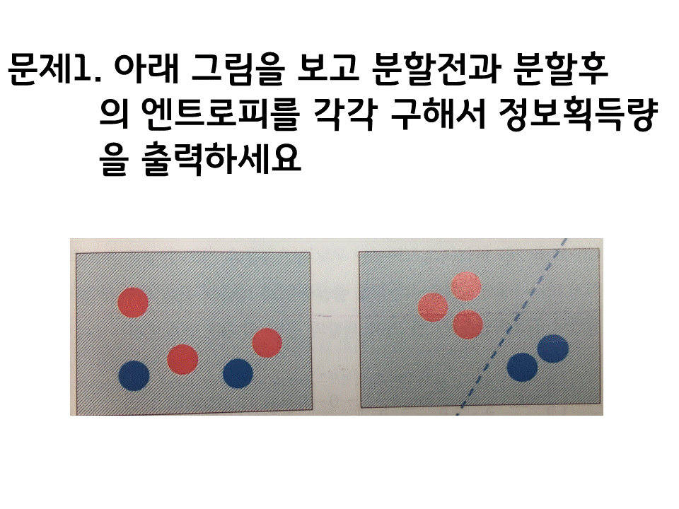

```r
rm()
x <- -((3/5)*log((3/5),2)) - ((2/5)*log((2/5),2))
round(x,2)
```

```
## [1] 0.97
```

```r
y <- 0.5 * (-(3/3)*log((3/3),2)) + 0.5 * (-(2/2)*log((2/2),2))
y
```

```
## [1] 0
```

```r
z = x - y
round(z,2)
```

```
## [1] 0.97
```

```r
# a<-(-3/5)*log2(3/5)
# b<-(-2/5)*log2(2/5)
# x<-a+b
#
# a2<-0.5*(-log2(1))
# b2<-0.5*(-log2(1))
# y<-a2+b2
#
# x-y
```

### 3. 의사결정 트리 실습( 화장품 구매 데이터, 지방간 데이터, 독일 은행의 대출여부 데이터 )

#### 실습1. 정보획득량 출력

#### 문제268.화장품 구매 고객 데이터 컬럼들에 대한 정보획득량을 구하시오

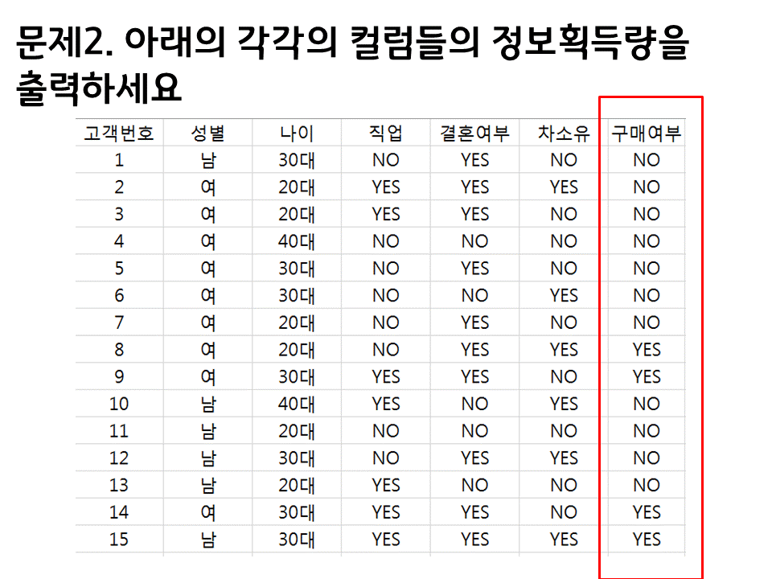

문제2

```r
# install.packages("FSelector")
library(FSelector)

skin <- read.csv("C:/data/skin.csv", header = T)

skin <- skin[,-1]  # 고객데이터 제외

                    # label ~ 나머지컬럼, 전체 data
x <- information.gain(cupon_react~., skin)

x
```

```
##        attr_importance
## gender     0.080610238
## age        0.019525931
## job        0.013737789
## marry      0.224337222
## car        0.006023806
```

#### 실습2. 결정트리 시각화

#### 문제269.화장품 고객 데이터를 가지고 의사결정 트리를 시각화하시오

```r
# install.packages("rpart")
# install.packages("rattle")
library(rpart)
library(rattle)
```

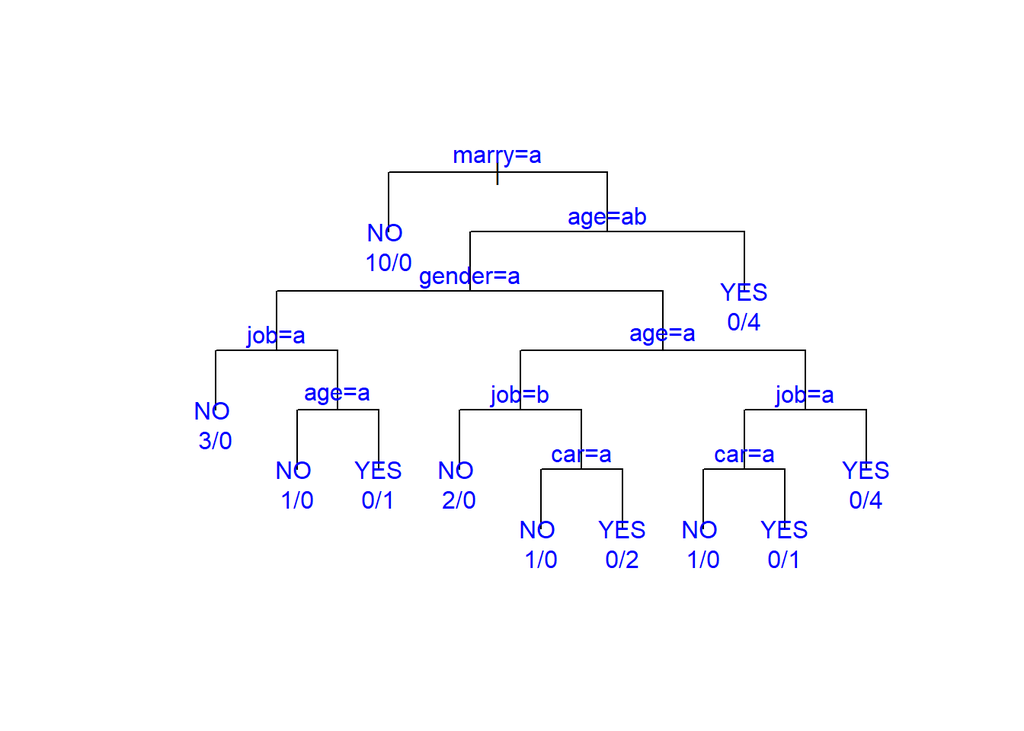

```r
tree1 <- rpart(cupon_react~., data = skin, control = rpart.control(minsplit = 2))

plot(tree1, compress = T, uniform = T, margin = 0.1)

text(tree1, use.n = T, col = "blue")
```

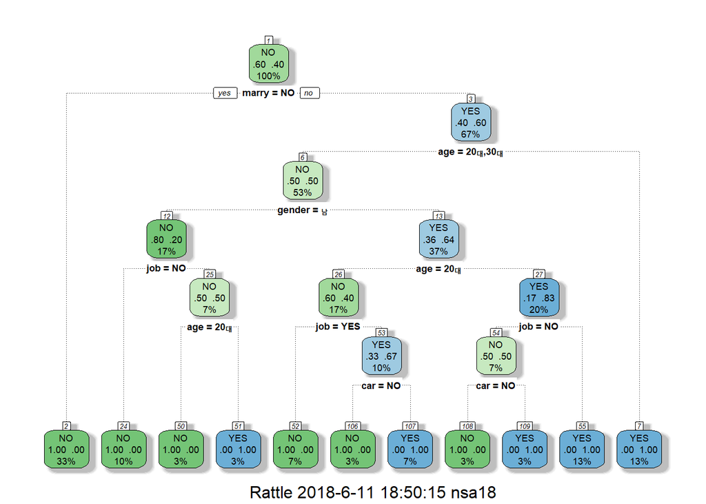

```r
fancyRpartPlot(tree1)
```

#### 문제270. 지방간 데이터의 정보획득량을 구해서 지방간을 일으키는데 가장 영향력이 큰 변수무엇인지 알아보시오

```r
library(FSelector)
fatliver <- read.csv("C:/data/fatliver2.csv", header = T)

head(fatliver)
```

```
##    AGE GENDER    DRINK SMOKING FATLIVER
## 1 40대   남자 음주많음    금연      yes
## 2 50대   여자 음주적음    금연       no
## 3 50대   여자 음주적음    금연       no
## 4 30대   남자 음주많음    흡연       no
## 5 60대   여자 음주적음    금연       no
## 6 40대   여자 음주적음    금연       no
```

```r
                    # label ~ 나머지컬럼, 전체 data
y <- information.gain(FATLIVER~., fatliver)

y
```

```
##         attr_importance
## AGE         0.022358781
## GENDER      0.019859086
## DRINK       0.008449112
## SMOKING     0.006801213
```

#### 문제271. 백화점 고객 구매 여부 데이터를 가지고 각 컬럼에 대해서 정보 획득량을 구하시오

```r
buy <- read.csv("C:/data/buy2.csv", header = T)

head(buy)
```

```
##   X cust_name card_yn review_yn before_buy_yn buy_yn
## 1 1     SCOTT       Y         Y             Y      Y
## 2 2     SMITH       Y         Y             Y      Y
## 3 3     ALLEN       N         N             Y      N
## 4 4     JONES       Y         N             N      Y
## 5 5      WARD       Y         Y             Y      Y
```

```r
buy <- buy[-1:-2]
head(buy)
```

```
##   card_yn review_yn before_buy_yn buy_yn
## 1       Y         Y             Y      Y
## 2       Y         Y             Y      Y
## 3       N         N             Y      N
## 4       Y         N             N      Y
## 5       Y         Y             Y      Y
```

```r
z <- information.gain(buy_yn~., buy)

z
```

```
##               attr_importance
## card_yn            0.50040242
## review_yn          0.22314355
## before_buy_yn      0.05053431
```

#### 문제272. 각 라인별로 좋은 패키지를 찾아서 가장예쁜 의사결정 트리를 그리시오

```r
# install.packages("party")
library(party)
```

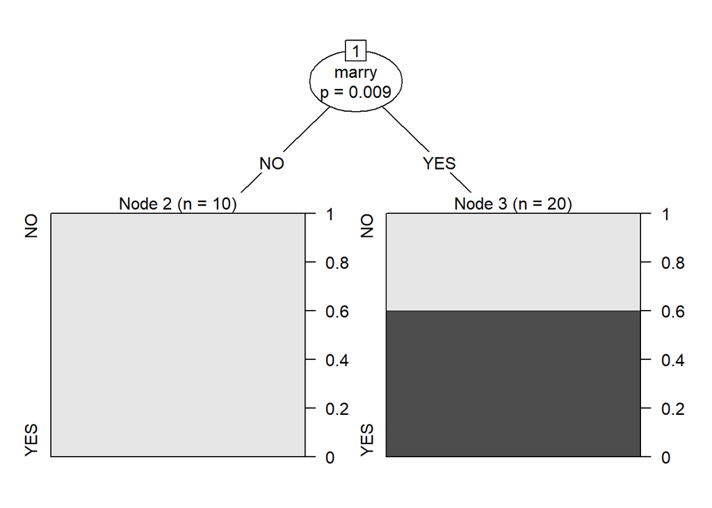

```r
library(rpart.plot)

tree1 <-ctree(cupon_react~.,skin)
plot(tree1)
```

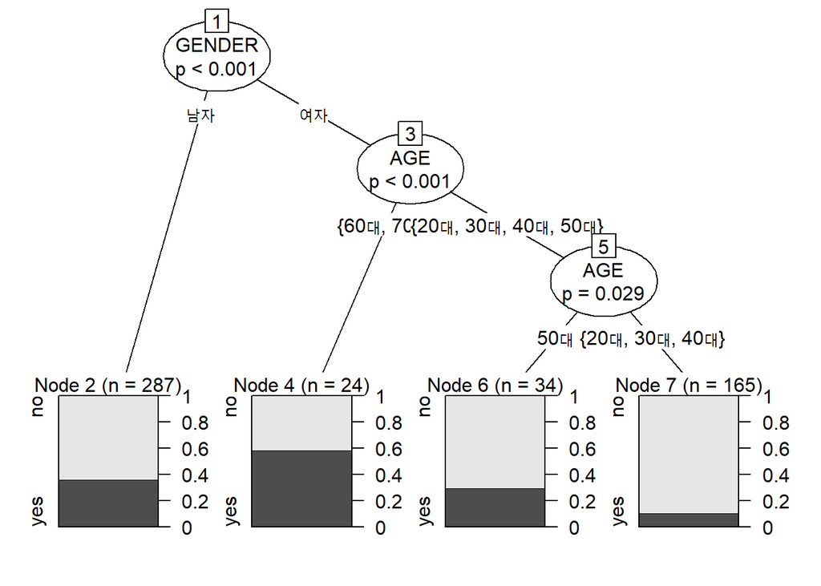

```r
tree2<-ctree(FATLIVER~.,fatliver)
plot(tree2)
```

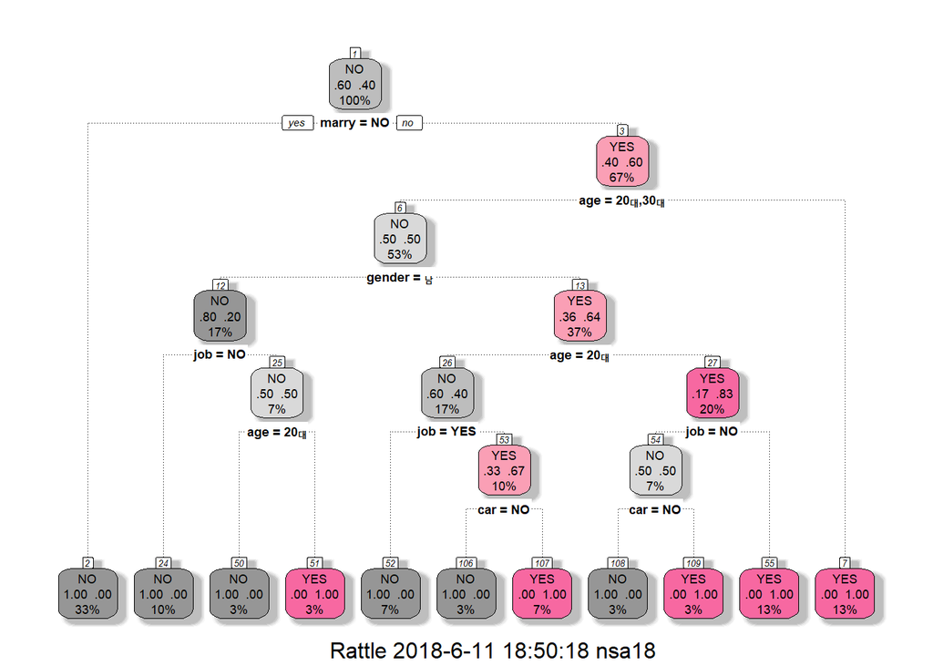

```r
tree3 <- rpart(cupon_react~.,data=skin, control=rpart.control(minsplit=2))
fancyRpartPlot(tree3,palettes = c("Greys","RdPu"))
```

[figure not shown]

```r
tree4 <- rpart(FATLIVER~.,data=fatliver, control=rpart.control(minsplit=2))
fancyRpartPlot(tree4)
```

#### 실습3. C5.0 패키지를 이용하여 분류 모델 생성

```r
# 1. 의사결정 패키지인 C50 패키지를 설치한다.
# install.packages("C50")
library(C50)

# 2. 화장품 고객 데이터를 shuffle 한다.
skin <- read.csv("C:/data/skin.csv", header = T)
skin <- skin[ ,-1]
print(paste("총 row수:",nrow(skin),"개"))
```

```
## [1] "총 row수: 30 개"
```

```r
print(paste("raw_data",head(skin)))
```

```
## [1] "raw_data c(1, 2, 2, 2, 2, 2)" "raw_data c(2, 1, 1, 3, 2, 2)"
## [3] "raw_data c(1, 2, 2, 1, 1, 1)" "raw_data c(2, 2, 2, 1, 2, 1)"
## [5] "raw_data c(1, 2, 1, 1, 1, 2)" "raw_data c(1, 1, 1, 1, 1, 1)"
```

```r
# 데이터 정제
skin$gender <- ifelse(skin$gender == "남", "M", "F")
# gsub -> substr
skin$age <- factor(gsub('대','', as.character(skin$age)))
print(paste("정제된 data",head(skin)))
```

```
## [1] "정제된 data c(\"M\", \"F\", \"F\", \"F\", \"F\", \"F\")"
## [2] "정제된 data c(2, 1, 1, 3, 2, 2)"
## [3] "정제된 data c(1, 2, 2, 1, 1, 1)"
## [4] "정제된 data c(2, 2, 2, 1, 2, 1)"
## [5] "정제된 data c(1, 2, 1, 1, 1, 2)"
## [6] "정제된 data c(1, 1, 1, 1, 1, 1)"
```

```r
# 조절할 것1_set.seed()
set.seed(11)
skin_shuffle <- skin[sample(nrow(skin)),]

# 3. 화장품 고객 데이터를 7대 3으로 트레인과 테스트로 나눈다._data 작음
train_num <- round(0.7*nrow(skin_shuffle),0)
skin_train <- skin_shuffle[1:train_num, ]
skin_test <- skin_shuffle[(train_num +1): nrow(skin_shuffle), ]

# 4. train data로 분류 모델을 생성한다.
                # label제외한 데이터, lable,
                # 조절할 것2_trials:laplace와 비슷
skin_model <- C5.0(skin_train[ ,-6], skin_train[ ,6], trials = 10)

# 5. 분류모델과 test data로 분류결과를 예측한다.
skin_result <- predict(skin_model, skin_test[ ,-6])

# 6. 이원교차표를 그려서 결과를 확인한다.
library(gmodels)

CrossTable(x = skin_test[,6],y=skin_result)
```

```
##
##
##    Cell Contents
## |-------------------------|
## |                       N |
## | Chi-square contribution |
## |           N / Row Total |
## |           N / Col Total |
## |         N / Table Total |
## |-------------------------|
##
##
## Total Observations in Table:  9
##
##
##                | skin_result
## skin_test[, 6] |        NO |       YES | Row Total |
## ---------------|-----------|-----------|-----------|
##             NO |         6 |         0 |         6 |
##                |     1.000 |     2.000 |           |
##                |     1.000 |     0.000 |     0.667 |
##                |     1.000 |     0.000 |           |
##                |     0.667 |     0.000 |           |
## ---------------|-----------|-----------|-----------|
##            YES |         0 |         3 |         3 |
##                |     2.000 |     4.000 |           |
##                |     0.000 |     1.000 |     0.333 |
##                |     0.000 |     1.000 |           |
##                |     0.000 |     0.333 |           |
## ---------------|-----------|-----------|-----------|
##   Column Total |         6 |         3 |         9 |
##                |     0.667 |     0.333 |           |
## ---------------|-----------|-----------|-----------|
##
##
```

> trials: 트레이닝 데이터를 반복 추출하여 표본을 여러개 만든 후 각 표본마다의 분류 모델을 생성해서 가장 좋은 모델을 고르는 방법, 부스팅하기 (단, 일정 수준이 지나면 수렴한다. 속도 문제다)

#### 실습. 독일은행의 대출 여부 데이터로 의사결정 트리 실습

모델: 과거의 data를 분석해보니 대출금의 상환 불이행자가 30%나 되어서 앞으로 30%이내로 떨어뜨리는게 은행의 목표

```r
# 1. 데이터를 로드한다.
credit <- read.csv("C:/data/credit.csv", header = T)
head(credit)
```

```
##   checking_balance months_loan_duration credit_history
## 1           < 0 DM                    6       critical
## 2       1 - 200 DM                   48           good
## 3          unknown                   12       critical
## 4           < 0 DM                   42           good
## 5           < 0 DM                   24           poor
## 6          unknown                   36           good
##                purpose amount savings_balance employment_duration
## 1 furniture/appliances   1169         unknown           > 7 years
## 2 furniture/appliances   5951        < 100 DM         1 - 4 years
## 3            education   2096        < 100 DM         4 - 7 years
## 4 furniture/appliances   7882        < 100 DM         4 - 7 years
## 5                  car   4870        < 100 DM         1 - 4 years
## 6            education   9055         unknown         1 - 4 years
##   percent_of_income years_at_residence age other_credit housing
## 1                 4                  4  67         none     own
## 2                 2                  2  22         none     own
## 3                 2                  3  49         none     own
## 4                 2                  4  45         none   other
## 5                 3                  4  53         none   other
## 6                 2                  4  35         none   other
##   existing_loans_count       job dependents phone default
## 1                    2   skilled          1   yes      no
## 2                    1   skilled          1    no     yes
## 3                    1 unskilled          2    no      no
## 4                    1   skilled          2    no      no
## 5                    2   skilled          2    no     yes
## 6                    1 unskilled          2   yes      no
```

```r
# 2. 데이터의 각 컬럼들을 이해한다
colnames(credit)
```

```
##  [1] "checking_balance"     "months_loan_duration" "credit_history"
##  [4] "purpose"              "amount"               "savings_balance"
##  [7] "employment_duration"  "percent_of_income"    "years_at_residence"
## [10] "age"                  "other_credit"         "housing"
## [13] "existing_loans_count" "job"                  "dependents"
## [16] "phone"                "default"
```

```r
# label column: default --> yes: 대출금 상환 안함, no : 대출금 상환
prop.table(table(credit$default))
```

```
##
##  no yes
## 0.7 0.3
```

```r
# account --> checking_balance : 예금, saving_balance: 적금

# amount: 대출금액 ( 100마르크 한화로 6~7만원)
summary(credit$amount)
```

```
##    Min. 1st Qu.  Median    Mean 3rd Qu.    Max.
##     250    1366    2320    3271    3972   18424
```

```r
# 3. 데이터 형식을 확인해본다
str(credit)
```

```
## 'data.frame':    1000 obs. of  17 variables:
##  $ checking_balance    : Factor w/ 4 levels "< 0 DM","> 200 DM",..: 1 3 4 1 1 4 4 3 4 3 ...
##  $ months_loan_duration: int  6 48 12 42 24 36 24 36 12 30 ...
##  $ credit_history      : Factor w/ 5 levels "critical","good",..: 1 2 1 2 4 2 2 2 2 1 ...
##  $ purpose             : Factor w/ 6 levels "business","car",..: 5 5 4 5 2 4 5 2 5 2 ...
##  $ amount              : int  1169 5951 2096 7882 4870 9055 2835 6948 3059 5234 ...
##  $ savings_balance     : Factor w/ 5 levels "< 100 DM","> 1000 DM",..: 5 1 1 1 1 5 4 1 2 1 ...
##  $ employment_duration : Factor w/ 5 levels "< 1 year","> 7 years",..: 2 3 4 4 3 3 2 3 4 5 ...
##  $ percent_of_income   : int  4 2 2 2 3 2 3 2 2 4 ...
##  $ years_at_residence  : int  4 2 3 4 4 4 4 2 4 2 ...
##  $ age                 : int  67 22 49 45 53 35 53 35 61 28 ...
##  $ other_credit        : Factor w/ 3 levels "bank","none",..: 2 2 2 2 2 2 2 2 2 2 ...
##  $ housing             : Factor w/ 3 levels "other","own",..: 2 2 2 1 1 1 2 3 2 2 ...
##  $ existing_loans_count: int  2 1 1 1 2 1 1 1 1 2 ...
##  $ job                 : Factor w/ 4 levels "management","skilled",..: 2 2 4 2 2 4 2 1 4 1 ...
##  $ dependents          : int  1 1 2 2 2 2 1 1 1 1 ...
##  $ phone               : Factor w/ 2 levels "no","yes": 2 1 1 1 1 2 1 2 1 1 ...
##  $ default             : Factor w/ 2 levels "no","yes": 1 2 1 1 2 1 1 1 1 2 ...
```

```r
# 4. 데이터를 shuffle시킨다.
set.seed(34)
credit_shuffle <- credit[sample(nrow(credit)), ]

# 5. 데이터를 9대 1로 나눈다.
train_num <- round(0.9 * nrow(credit_shuffle), 0)

credit_train <- credit_shuffle[1:train_num, ]
credit_test <- credit_shuffle[(train_num)+1 : nrow(credit_shuffle), ]

# 6. C5.0패키지와 훈련데이터의 모델을 생성한다.
library(C50)
ncol <- which(colnames(credit_train) == "default")
credit_model <- C5.0(credit_train[ ,-ncol], credit_train[ ,ncol], trials = 100)

# 7. 모델과 테스트 데이터로 결과 예측
credit_result <- predict(credit_model, credit_test[ ,-ncol])

# 8. 이원교차표로 결과를 살펴본다.
library(gmodels)

CrossTable(credit_test[,ncol], credit_result)
```

```
##
##
##    Cell Contents
## |-------------------------|
## |                       N |
## | Chi-square contribution |
## |           N / Row Total |
## |           N / Col Total |
## |         N / Table Total |
## |-------------------------|
##
##
## Total Observations in Table:  100
##
##
##                     | credit_result
## credit_test[, ncol] |        no |       yes | Row Total |
## --------------------|-----------|-----------|-----------|
##                  no |        67 |         8 |        75 |
##                     |     1.014 |     3.813 |           |
##                     |     0.893 |     0.107 |     0.750 |
##                     |     0.848 |     0.381 |           |
##                     |     0.670 |     0.080 |           |
## --------------------|-----------|-----------|-----------|
##                 yes |        12 |        13 |        25 |
##                     |     3.041 |    11.440 |           |
##                     |     0.480 |     0.520 |     0.250 |
##                     |     0.152 |     0.619 |           |
##                     |     0.120 |     0.130 |           |
## --------------------|-----------|-----------|-----------|
##        Column Total |        79 |        21 |       100 |
##                     |     0.790 |     0.210 |           |
## --------------------|-----------|-----------|-----------|
##
##
```

#### 연습

```r
library(C50)

skin <- read.csv("C:/data/skin.csv", header = T)
skin <- skin[ ,-1]

# 데이터 정제
skin$gender <- ifelse(skin$gender == "남", "M", "F")
skin$age <- factor(gsub('대','', as.character(skin$age)))

# 조절할 것1_set.seed()
set.seed(11)
skin_shuffle <- skin[sample(nrow(skin)),]


train_num <- round(0.7*nrow(skin_shuffle),0)
skin_train <- skin_shuffle[1:train_num, ]
skin_test <- skin_shuffle[(train_num +1): nrow(skin_shuffle), ]

                # 조절할 것2_trials:laplace와 비슷
skin_model <- C5.0(skin_train[ ,-6], skin_train[ ,6], trials = 10)

skin_result <- predict(skin_model, skin_test[ ,-6])

library(gmodels)
CrossTable(x = skin_test[,6],y=skin_result)
```

```
##
##
##    Cell Contents
## |-------------------------|
## |                       N |
## | Chi-square contribution |
## |           N / Row Total |
## |           N / Col Total |
## |         N / Table Total |
## |-------------------------|
##
##
## Total Observations in Table:  9
##
##
##                | skin_result
## skin_test[, 6] |        NO |       YES | Row Total |
## ---------------|-----------|-----------|-----------|
##             NO |         6 |         0 |         6 |
##                |     1.000 |     2.000 |           |
##                |     1.000 |     0.000 |     0.667 |
##                |     1.000 |     0.000 |           |
##                |     0.667 |     0.000 |           |
## ---------------|-----------|-----------|-----------|
##            YES |         0 |         3 |         3 |
##                |     2.000 |     4.000 |           |
##                |     0.000 |     1.000 |     0.333 |
##                |     0.000 |     1.000 |           |
##                |     0.000 |     0.333 |           |
## ---------------|-----------|-----------|-----------|
##   Column Total |         6 |         3 |         9 |
##                |     0.667 |     0.333 |           |
## ---------------|-----------|-----------|-----------|
##
##
```

```r
# 1. data하나를 생성한다.

cust_data1 <- data.frame(gender = 'F', age = 30, job = 'YES', marry = 'YES', car = 'NO')
cust_data1
```

```
##   gender age job marry car
## 1      F  30 YES   YES  NO
```

```r
# 2. 쿠폰반응 유무를 예측한다.
skin_result <- predict(skin_model, cust_data1)
skin_result
```

```
## [1] YES
## Levels: NO YES
```

#### 문제275. skin_model 을 이용해서 고객이 쿠폰반응이 있는 고객인지 없는 고객인지 예측하는 프로그램을 생성하시오

```r
skin_func <- function(){
  gender <- readline(prompt ="성별을 입력하세요 예) F, M: ")
  age <- readline(prompt ="나이를 입력하세요 예) 20, 30, 40: ")
  job <- readline(prompt ="직업 유무를 입력하세요 예) YES, NO: ")
  marry <- readline(prompt ="결혼 여부를 입력하세요 예) YES, NO: ")
  car <- readline(prompt ="차 소유 여부를 입력하세요 예) YES, NO: ")

  # 분석 쿼리
  library(C50)

  skin <- read.csv("C:/data/skin.csv", header = T)
  skin <- skin[ ,-1]

  # 데이터 정제
  skin$gender <- ifelse(skin$gender == "남", "M", "F")
  skin$age <- factor(gsub('대','', as.character(skin$age)))

  # 조절할 것1_set.seed()
  set.seed(11)
  skin_shuffle <- skin[sample(nrow(skin)),]


  train_num <- round(0.7*nrow(skin_shuffle),0)
  skin_train <- skin_shuffle[1:train_num, ]
  skin_test <- skin_shuffle[(train_num +1): nrow(skin_shuffle), ]


                  # 조절할 것2_trials:laplace와 비슷
  skin_model <- C5.0(skin_train[ ,-6], skin_train[ ,6], trials = 10)

  # 1. data하나를 생성한다.

  cust_data1 <- data.frame(gender = toupper(gender), age = as.numeric(age), job = toupper(job),
                            marry = toupper(marry), car = toupper(car))

  # 2. 쿠폰반응 유무를 예측한다.
  skin_result <- predict(skin_model, cust_data1)
  print(paste("쿠폰반응 ", skin_result,"인 고객입니다."))

  library(gmodels)
  skin_result <- predict(skin_model, skin_test[ ,-6])
  CrossTable(x = skin_test[,6], y=skin_result)
}

# skin_func()
```

#### 문제276. 의사결정 트리 자동화 스크립트 생성.

```r
decision_fun <- function(){
  rm()
  print("분석할 csv파일을 입력하세요 ")
  data <- file.choose()
  na.string <- NA
  # 연속형데이터는 factor로 변환하면....안돼
  table1 <- read.csv(data, header = T, na.string = na.string)

  d_col <- menu(c(colnames(table1),'non'), title="삭제할 컬럼을 선택하시오 ")

  table1 <- table1[,-d_col]

  l_col <- menu(colnames(table1), title="label이 될 컬럼을 선택하시오 ")

    # 연속형데이터는 factor로 변환하지 않는다.

    # 팩터 라벨 한글 제거
  fctr_ls <- which( sapply(table1, class) == "factor" )

  if( length(fctr_ls) !=0 ) {

    cat('***주의***\nFactor에 한글이 포함되어 있으면 에러가 발생할 수 있습니다. \nFactor 라벨을 영문 혹은 숫자로 변경하십시오.\n\n')

    while( TRUE ) {

      chg_num <- menu(c('SKIP', colnames(table1)[fctr_ls]) ,
                       title = "라벨을 변환할 팩터컬럼을 선택하세요\n-> 더이상 변환할 컬럼이 없다면 SKIP을 선택합니다.")

      if( chg_num == 1 ) break

      chng_lv <- NULL
      lv <- levels( table1[,fctr_ls[chg_num-1]] )

      for( i in 1:length(lv) ) {

        chg_lv <- c(chng_lv,
                     readline( paste('기존 :',
                                     lv[i],
                                     '-> 변경 : ')) )
      }

      levels( table1[,fctr_ls[chg_num-1]] ) <- chg_lv
    }
  }

  trials <- readline(prompt = "trials 값을 입력하세요 ")

  # 분석 쿼리
  library(C50)
  library(gmodels)
  library(rpart)
  library(rattle)


  # 조절할 것1_set.seed()
  set.seed(11)
  table_shuffle <- table1[sample(nrow(table1)),]


  train_num <- round(0.7*nrow(table_shuffle),0)
  table_train <- table_shuffle[1:train_num, ]
  table_test <- table_shuffle[(train_num +1): nrow(table_shuffle), ]

  l_col <-  colnames(table1)[l_col]
  ncol1 <- which(colnames(table1) == l_col)

  # 조절할 것2_trials:laplace와 비슷
  model <- C5.0(table_train[ ,-ncol1], table_train[ ,ncol1], trials = as.numeric(trials))
  result <- predict(model, table_test[ ,-ncol1])

  CrossTable(x = table_test[,ncol1], y= result)

  # as.formula와 paste로 ~.을 붙여야한다.
  tree <- rpart(label~. , data=data.frame(table1[,-ncol1], label = table1[,l_col]),
                control=rpart.control(minsplit=2))
  fancyRpartPlot(tree,palettes = c("Greys","RdPu"))
}

# 근호오빠꺼
# decision_func <- function(){
#   library('rpart')
#   library('gmodels')
#   library('rattle')
#
#   #데이터 입력
#
#   # NA 처리
#   na.string <- NULL
#
#   while( TRUE ){
#     na.val <- readline('불러올 파일에서 NA로 취급할 문자를 입력합니다. (없다면 skip을 입력합니다.) : ')
#
#     if(tolower(na.val) == 'skip') break
#
#     na.string <- c(na.string, na.val)
#
#   }
#
#   #HEADER
#   header  <- menu(c('Yes','No'), title = '파일에서 헤더를 불러옵니까?')
#   header  <- ifelse(header == 1, 1, 0 )
#   dc_data <- read.csv(file.choose(), header = header ,na.string = na.string )
#
#   #컬럼 삭제
#   while( TRUE ) {
#     del_num <- menu(c('SKIP', colnames(dc_data)) ,
#                     title = "삭제할 컬럼을 선택하세요 \n\n-> 더이상 삭제할 컬럼이 없다면 SKIP을 선택합니다.")
#
#     if( del_num == 1 ) break
#
#     dc_data <- dc_data[,-(del_num-1)]
#
#   }
#
#
#   # 팩터 라벨 한글 제거
#   fctr_ls <- which( sapply(dc_data, class) == "factor" )
#
#   if( length(fctr_ls) !=0 ) {
#
#     cat('***주의***\nFactor에 한글이 포함되어 있으면 에러가 발생할 수 있습니다. \nFactor 라벨을 영문 혹은 숫자로 변경하십시오.\n\n')
#
#     while( TRUE ) {
#
#       chng_num <- menu(c('SKIP', colnames(dc_data)[fctr_ls]) ,
#                        title = "라벨을 변환할 팩터컬럼을 선택하세요\n-> 더이상 변환할 컬럼이 없다면 SKIP을 선택합니다.")
#
#       if( chng_num == 1 ) break
#
#       chng_lv <- NULL
#       lv <- levels( dc_data[,fctr_ls[chng_num-1]] )
#
#       for( i in 1:length(lv) ) {
#
#         chng_lv <- c(chng_lv,
#                      readline( paste('기존 :',
#                                      lv[i],
#                                      '-> 변경 : ')) )
#       }
#
#       levels( dc_data[,fctr_ls[chng_num-1]] ) <- chng_lv
#
#
#     }
#   }
#
#   y <- menu(colnames(dc_data), title = "라벨 컬럼을 선택하세요 ")
#
#
#   while( TRUE ){
#     trials <- readline('TRIALS 값을 입력합니다. 기본값은 1 입니다.(1 ~ 100) : ')
#     trials <- as.numeric(trials)
#
#     # 트레이닝 , 테스트 셋
#     #set.seed(1)
#
#     train_rate <- readline('트레이닝 셋의 비율을입력합니다. (0 ~ 1) : ')
#     train_rate <- as.numeric(train_rate)
#
#     train_cnt  <- round( train_rate*dim(dc_data)[1] )
#     train_indx <- sample(1:dim(dc_data)[1], train_cnt, replace = F)
#
#     dc_train <- dc_data[train_indx,]
#     dc_test  <- dc_data[-train_indx,]
#     colnames(dc_train)[y] <- 'label'
#
#     # 모델
#     model <- rpart(label ~ ., data = dc_train,
#                    control = rpart.control(minsplit = 2))
#
#     # 예측
#     result <- predict(model, dc_test[,-y], type = 'class' )
#
#     #교차표
#     CrossTable(dc_test[,y],
#                result,
#                prop.c = F,
#                prop.t = F,
#                prop.chisq = F )
#     # PLOT
#     graphics.off()
#     X11()
#     fancyRpartPlot(model)
#
#     rp <- menu(c('Yes (다시수행)','No (종료)'), title = 'Input Arguments 를 조정하고 분석을 다시 수행 할 수 있습니다.')
#     if( rp == 2 ) break
#   }
#   cat('종료합니다...')
# }
#
# decision_func()
```